# An Analysis of 2019 Cyclistic Bike Ridership

Marc Himmel

## Introduction

Cyclistic is a bike-share company in Chicago launched in 2016 with more than 5,800 bicycles and 600 docking stations.

The company offers flexible pricing plans: single-ride passes, full-day passes, and annual memberships. Riders who purchase a single-ride pass or a full-day pass are referred to as “casual riders”, whereas customers who purchase an annual membership are referred to as “members”.

Cyclistic’s finance strategists have determined that annual members are much more profitable than casual riders. A key part of their business strategy, therefore, relies on converting casual riders into annual members. To target their marketing campaign specifically at their casual rider customer base, the Cyclistic marketing analysts need to better understand how annual members and casual riders differ.

## Key Analysis Question

**How do annual members and casual riders use Cyclistic bikes differently?**

## Data

The data used for this analysis comes from the Cyclistic Historical Trip Data. This is a public data set. All personally identifiable information has been removed. Without personally identifiable data present, it is impossible to link multiple rides to the same account. Therefore, every ride is treated as a singular, independent event. This report focuses solely on data recorded from 2019.

The data used in this report, as well as historical trip data from other years, can be found here: [Cyclistic Historical Trip Data](https://divvy-tripdata.s3.amazonaws.com/index.html)

#### Setting up R environment

```r
# Installing packages and loading libraries
#install.packages("tidyverse")
#install.packages("gplots")
#install.packages("scales")
#install.packages("cowplot")
#install.packages("formattable")
#install.packages("rmarkdown")
#install.packages("ggtext")
library(tidyverse)
library(gplots)
library(scales)
library(cowplot)
library(formattable)
library(rmarkdown)
library(ggtext)
```

#### Importing the Data

This data set was pulled from the Google Data Analytics course Case Study 1.  
The data can be found here: [Cyclistic Historical Trip Data](https://divvy-tripdata.s3.amazonaws.com/index.html)

```r
#Import files
q1df <- read.csv("C:/Users/march/OneDrive/Desktop/Courses/Google Certificate/8- Google Data Analytics Capstone- Complete a Case Study/Case Study 1/RAW data/Divvy_Trips_2019_Q1 RAW.csv")
q2df <- read.csv("C:/Users/march/OneDrive/Desktop/Courses/Google Certificate/8- Google Data Analytics Capstone- Complete a Case Study/Case Study 1/RAW data/Divvy_Trips_2019_Q2 RAW.csv")
q3df <- read.csv("C:/Users/march/OneDrive/Desktop/Courses/Google Certificate/8- Google Data Analytics Capstone- Complete a Case Study/Case Study 1/RAW data/Divvy_Trips_2019_Q3 RAW.csv")
q4df <- read.csv("C:/Users/march/OneDrive/Desktop/Courses/Google Certificate/8- Google Data Analytics Capstone- Complete a Case Study/Case Study 1/RAW data/Divvy_Trips_2019_Q4 RAW.csv")
```

Once imported, I take a quick glance at the four quarterly data frames to get familiar with their contents and see their structures.

```r
glimpse(q1df)
```

```
## Rows: 365,069
## Columns: 12
## $ trip_id           <int> 21742443, 21742444, 21742445, 21742446, 21742447, 21…
## $ start_time        <chr> "2019-01-01 00:04:37", "2019-01-01 00:08:13", "2019-…
## $ end_time          <chr> "2019-01-01 00:11:07", "2019-01-01 00:15:34", "2019-…
## $ bikeid            <int> 2167, 4386, 1524, 252, 1170, 2437, 2708, 2796, 6205,…
## $ tripduration      <chr> "390.0", "441.0", "829.0", "1,783.0", "364.0", "216.…
## $ from_station_id   <int> 199, 44, 15, 123, 173, 98, 98, 211, 150, 268, 299, 2…
## $ from_station_name <chr> "Wabash Ave & Grand Ave", "State St & Randolph St", …
## $ to_station_id     <int> 84, 624, 644, 176, 35, 49, 49, 142, 148, 141, 295, 4…
## $ to_station_name   <chr> "Milwaukee Ave & Grand Ave", "Dearborn St & Van Bure…
## $ usertype          <chr> "Subscriber", "Subscriber", "Subscriber", "Subscribe…
## $ gender            <chr> "Male", "Female", "Female", "Male", "Male", "Female"…
## $ birthyear         <int> 1989, 1990, 1994, 1993, 1994, 1983, 1984, 1990, 1995…
```

```r
glimpse(q2df)
```

```
## Rows: 1,108,163
## Columns: 12
## $ X01...Rental.Details.Rental.ID                    <int> 22178529, 22178530, …
## $ X01...Rental.Details.Local.Start.Time             <chr> "2019-04-01 00:02:22…
## $ X01...Rental.Details.Local.End.Time               <chr> "2019-04-01 00:09:48…
## $ X01...Rental.Details.Bike.ID                      <int> 6251, 6226, 5649, 41…
## $ X01...Rental.Details.Duration.In.Seconds.Uncapped <chr> "446.0", "1,048.0", …
## $ X03...Rental.Start.Station.ID                     <int> 81, 317, 283, 26, 20…
## $ X03...Rental.Start.Station.Name                   <chr> "Daley Center Plaza"…
## $ X02...Rental.End.Station.ID                       <int> 56, 59, 174, 133, 12…
## $ X02...Rental.End.Station.Name                     <chr> "Desplaines St & Kin…
## $ User.Type                                         <chr> "Subscriber", "Subsc…
## $ Member.Gender                                     <chr> "Male", "Female", "M…
## $ X05...Member.Details.Member.Birthday.Year         <int> 1975, 1984, 1990, 19…
```

```r
glimpse(q3df)
```

```
## Rows: 1,640,718
## Columns: 12
## $ trip_id           <int> 23479388, 23479389, 23479390, 23479391, 23479392, 23…
## $ start_time        <chr> "2019-07-01 00:00:27", "2019-07-01 00:01:16", "2019-…
## $ end_time          <chr> "2019-07-01 00:20:41", "2019-07-01 00:18:44", "2019-…
## $ bikeid            <int> 3591, 5353, 6180, 5540, 6014, 4941, 3770, 5442, 2957…
## $ tripduration      <chr> "1,214.0", "1,048.0", "1,554.0", "1,503.0", "1,213.0…
## $ from_station_id   <int> 117, 381, 313, 313, 168, 300, 168, 313, 43, 43, 511,…
## $ from_station_name <chr> "Wilton Ave & Belmont Ave", "Western Ave & Monroe St…
## $ to_station_id     <int> 497, 203, 144, 144, 62, 232, 62, 144, 195, 195, 84, …
## $ to_station_name   <chr> "Kimball Ave & Belmont Ave", "Western Ave & 21st St"…
## $ usertype          <chr> "Subscriber", "Customer", "Customer", "Customer", "C…
## $ gender            <chr> "Male", "", "", "", "", "Male", "", "", "", "", "", …
## $ birthyear         <int> 1992, NA, NA, NA, NA, 1990, NA, NA, NA, NA, NA, NA, …
```

```r
glimpse(q4df)
```

```
## Rows: 704,054
## Columns: 12
## $ trip_id           <int> 25223640, 25223641, 25223642, 25223643, 25223644, 25…
## $ start_time        <chr> "2019-10-01 00:01:39", "2019-10-01 00:02:16", "2019-…
## $ end_time          <chr> "2019-10-01 00:17:20", "2019-10-01 00:06:34", "2019-…
## $ bikeid            <int> 2215, 6328, 3003, 3275, 5294, 1891, 1061, 1274, 6011…
## $ tripduration      <chr> "940.0", "258.0", "850.0", "2,350.0", "1,867.0", "37…
## $ from_station_id   <int> 20, 19, 84, 313, 210, 156, 84, 156, 156, 336, 77, 19…
## $ from_station_name <chr> "Sheffield Ave & Kingsbury St", "Throop (Loomis) St …
## $ to_station_id     <int> 309, 241, 199, 290, 382, 226, 142, 463, 463, 336, 50…
## $ to_station_name   <chr> "Leavitt St & Armitage Ave", "Morgan St & Polk St", …
## $ usertype          <chr> "Subscriber", "Subscriber", "Subscriber", "Subscribe…
## $ gender            <chr> "Male", "Male", "Female", "Male", "Male", "Female", …
## $ birthyear         <int> 1987, 1998, 1991, 1990, 1987, 1994, 1991, 1995, 1993…
```

#### Preparing the Data

Before the four data frames can be merged into one, their contents need to be standardized and prepared. This includes removing columns, replacing columns, renaming columns, reordering columns, and creating new columns that will be important for the upcoming analysis.

```r
# Remove bike id columns
q1df <- subset(q1df, select = -c(bikeid))
q2df <- subset(q2df, select = -c(X01...Rental.Details.Bike.ID))
q3df <- subset(q3df, select = -c(bikeid))
q4df <- subset(q4df, select = -c(bikeid))


#### FIX q1df "duration_secs" column...remove commas, convert to type numeric,...
####...replace old duration column with newly created one, and add new "duration_mins" column

q1_dur_secs <- gsub(",", "", q1df$tripduration)
q1_dur_secs_numeric <- as.numeric(q1_dur_secs)
q1_dur_mins <- ceiling(q1_dur_secs_numeric / 60)
q1df <- subset(q1df, select = -c(tripduration))
q1df <- cbind(q1df, q1_dur_secs_numeric)
q1df <- cbind(q1df, q1_dur_mins)


#...Repeat for q2df
q2_dur_secs <- gsub(",", "", q2df$X01...Rental.Details.Duration.In.Seconds.Uncapped)
q2_dur_secs_numeric <- as.numeric(q2_dur_secs)
q2_dur_mins <- ceiling(q2_dur_secs_numeric / 60)
q2df <- subset(q2df, select = -c(X01...Rental.Details.Duration.In.Seconds.Uncapped))
q2df <- cbind(q2df, q2_dur_secs_numeric)
q2df <- cbind(q2df, q2_dur_mins)



#...Repeat for q3df
q3_dur_secs <- gsub(",", "", q3df$tripduration)
q3_dur_secs_numeric <- as.numeric(q3_dur_secs)
q3_dur_mins <- ceiling(q3_dur_secs_numeric / 60)
q3df <- subset(q3df, select = -c(tripduration))
q3df <- cbind(q3df, q3_dur_secs_numeric)
q3df <- cbind(q3df, q3_dur_mins)



#...Repeat for q4df
q4_dur_secs <- gsub(",", "", q4df$tripduration)
q4_dur_secs_numeric <- as.numeric(q4_dur_secs)
q4_dur_mins <- ceiling(q4_dur_secs_numeric / 60)
q4df <- subset(q4df, select = -c(tripduration))
q4df <- cbind(q4df, q4_dur_secs_numeric)
q4df <- cbind(q4df, q4_dur_mins)


# Create age column in each dataframe
q1df$age <- 2019 - q1df$birthyear
q2df$age <- 2019 - q2df$X05...Member.Details.Member.Birthday.Year
q3df$age <- 2019 - q3df$birthyear
q4df$age <- 2019 - q4df$birthyear


# Remove "birthyear" column from each dataframe
q1df <- subset(q1df, select = -c(birthyear))
q2df <- subset(q2df, select = -c(X05...Member.Details.Member.Birthday.Year))
q3df <- subset(q3df, select = -c(birthyear))
q4df <- subset(q4df, select = -c(birthyear))


# Add "day of week" column to each dataframe. Sunday=1, Monday=2....etc
q1df$day_of_week <- wday(q1df$start_time)
q2df$day_of_week <- wday(q2df$X01...Rental.Details.Local.Start.Time)
q3df$day_of_week <- wday(q3df$start_time)
q4df$day_of_week <- wday(q4df$start_time)


#### Make column names in each dataframe uniform

# Renaming q1df columns
colnames(q1df)[10] = "duration_seconds"
colnames(q1df)[11] = "duration_mins"

# Renaming q2df columns
colnames(q2df)[1] = "trip_id"
colnames(q2df)[2] = "start_time"
colnames(q2df)[3] = "end_time"
colnames(q2df)[4] = "from_station_id"
colnames(q2df)[5] = "from_station_name"
colnames(q2df)[6] = "to_station_id"
colnames(q2df)[7] = "to_station_name"
colnames(q2df)[8] = "usertype"
colnames(q2df)[9] = "gender"
colnames(q2df)[10] = "duration_seconds"
colnames(q2df)[11] = "duration_mins"


# Renaming q3df columns
colnames(q3df)[10] = "duration_seconds"
colnames(q3df)[11] = "duration_mins"


# Renaming q4df columns
colnames(q4df)[10] = "duration_seconds"
colnames(q4df)[11] = "duration_mins"
```

#### Merging the Data

```r
fulldf <- rbind(q1df, q2df, q3df, q4df)
```

All of the data now exists in a single data frame. A few more columns need to be created and/or fixed before the data can be cleaned.

```r
# Add new column that specifies name of day of week
day_of_week_name <- fulldf$day_of_week
fulldf <- cbind(fulldf, day_of_week_name)

fulldf$day_of_week_name <- replace(fulldf$day_of_week_name, fulldf$day_of_week_name == 1, 'Sunday')
fulldf$day_of_week_name <- replace(fulldf$day_of_week_name, fulldf$day_of_week_name == 2, 'Monday')
fulldf$day_of_week_name <- replace(fulldf$day_of_week_name, fulldf$day_of_week_name == 3, 'Tuesday')
fulldf$day_of_week_name <- replace(fulldf$day_of_week_name, fulldf$day_of_week_name == 4, 'Wednesday')
fulldf$day_of_week_name <- replace(fulldf$day_of_week_name, fulldf$day_of_week_name == 5, 'Thursday')
fulldf$day_of_week_name <- replace(fulldf$day_of_week_name, fulldf$day_of_week_name == 6, 'Friday')
fulldf$day_of_week_name <- replace(fulldf$day_of_week_name, fulldf$day_of_week_name == 7, 'Saturday')



# Fix "start_time" and "end_time" columns ###

# Split up start_time column into two columns: "start_date" and "start_time"
colnames(fulldf)[2] = "FULL_start_time"   #changing current column name to avoid confusion
fulldf <- fulldf %>%
  separate(FULL_start_time, c('start_date', 'start_time'), sep = " ")

#...Repeat process for end_time column
colnames(fulldf)[4] = "FULL_end_time"   #changing current column name to avoid confusion
fulldf <- fulldf %>%
  separate(FULL_end_time, c('end_date', 'end_time'), sep = " ")


# Convert start_date and end_date columns into uniform formats, then into proper "date" class
fulldf$start_date <- ymd(parse_date_time(fulldf$start_date, c("%m/%d/%Y", "%y-%m-%d")))
fulldf$end_date <- ymd(parse_date_time(fulldf$end_date, c("%m/%d/%Y", "%y-%m-%d")))

# Convert 'start_time' column into uniform format, remove first 11 characters (made-up date stamp), then convert to 'hms'
start_time_as_date <- parse_date_time(fulldf$start_time, c("%H:%M", "%H:%M:%S"))
start_time_as_date_tidy <- gsub("^.{0,11}", "", start_time_as_date)
fulldf$start_time <- hms(start_time_as_date_tidy)

#...Repeat for 'end_time' column...
end_time_as_date <- parse_date_time(fulldf$end_time, c("%H:%M", "%H:%M:%S"))
end_time_as_date_tidy <- gsub("^.{0,11}", "", end_time_as_date)
fulldf$end_time <- hms(end_time_as_date_tidy)




# Add new column for name of month the ride starts in
fulldf$start_date_months <- months(fulldf$start_date)


# Add new column that specifies the NUMBER of the Month (taken from 'start_date_months' column)
Number_of_Month <- fulldf$start_date_months
fulldf <- cbind(fulldf, Number_of_Month)
fulldf$Number_of_Month <- replace(fulldf$Number_of_Month, fulldf$Number_of_Month == 'January', 1)
fulldf$Number_of_Month <- replace(fulldf$Number_of_Month, fulldf$Number_of_Month == 'February', 2)
fulldf$Number_of_Month <- replace(fulldf$Number_of_Month, fulldf$Number_of_Month == 'March', 3)
fulldf$Number_of_Month <- replace(fulldf$Number_of_Month, fulldf$Number_of_Month == 'April', 4)
fulldf$Number_of_Month <- replace(fulldf$Number_of_Month, fulldf$Number_of_Month == 'May', 5)
fulldf$Number_of_Month <- replace(fulldf$Number_of_Month, fulldf$Number_of_Month == 'June', 6)
fulldf$Number_of_Month <- replace(fulldf$Number_of_Month, fulldf$Number_of_Month == 'July', 7)
fulldf$Number_of_Month <- replace(fulldf$Number_of_Month, fulldf$Number_of_Month == 'August', 8)
fulldf$Number_of_Month <- replace(fulldf$Number_of_Month, fulldf$Number_of_Month == 'September', 9)
fulldf$Number_of_Month <- replace(fulldf$Number_of_Month, fulldf$Number_of_Month == 'October', 10)
fulldf$Number_of_Month <- replace(fulldf$Number_of_Month, fulldf$Number_of_Month == 'November', 11)
fulldf$Number_of_Month <- replace(fulldf$Number_of_Month, fulldf$Number_of_Month == 'December', 12)



# Convert "Number_of_month" from type char to numeric, then rename
fulldf$Number_of_Month <- as.numeric(fulldf$Number_of_Month)
colnames(fulldf)[18] = "number_of_month"


# Change name of usertypes from Subscriber/Customer  to  Annual Member/Casual Rider
fulldf$usertype <-ifelse(fulldf$usertype == "Subscriber", "Annual Member", "Casual Rider")
```

#### Cleaning the Data

First, each column is checked for “NA” values.

```r
# Check for NA
sum(is.na(fulldf$trip_id))
## [1] 0
sum(is.na(fulldf$start_date))
## [1] 0
sum(is.na(fulldf$start_time))
## [1] 0
sum(is.na(fulldf$end_date))
## [1] 0
sum(is.na(fulldf$end_time))
## [1] 0
sum(is.na(fulldf$from_station_id))
## [1] 0
sum(is.na(fulldf$from_station_name))
## [1] 0
sum(is.na(fulldf$to_station_id))
## [1] 0
sum(is.na(fulldf$to_station_name))
## [1] 0
sum(is.na(fulldf$usertype))
## [1] 0
sum(is.na(fulldf$gender))
## [1] 0
sum(is.na(fulldf$duration_seconds))
## [1] 0
sum(is.na(fulldf$duration_mins))
## [1] 0
sum(is.na(fulldf$age))#................538,751 NA's in this column
## [1] 538751
sum(is.na(fulldf$day_of_week))
## [1] 0
sum(is.na(fulldf$day_of_week_name))
## [1] 0
sum(is.na(fulldf$start_date_months))
## [1] 0
sum(is.na(fulldf$number_of_month))
## [1] 0
```

538,751 rows of data show NA for the customer’s age. The decision is made to drop these rows. This represents a significant portion of the data set (14%), however the decision is justified due to customer age playing a large factor in the analysis. Additionally, there is still a significant amount of data left over.

```r
# Drop rows with NA values
fulldf <- fulldf %>%
  drop_na()
```

Next, columns are checked for missing values.

```r
# Check for blanks
sum(fulldf$trip_id == "")
## [1] 0
sum(fulldf$start_date == "")
## [1] NA
sum(fulldf$start_time == "")
## [1] NA
sum(fulldf$end_date == "")
## [1] NA
sum(fulldf$end_time == "")
## [1] NA
sum(fulldf$from_station_id == "")
## [1] 0
sum(fulldf$from_station_name == "")
## [1] 0
sum(fulldf$to_station_id == "")
## [1] 0
sum(fulldf$to_station_name == "")
## [1] 0
sum(fulldf$usertype == "")
## [1] 0
sum(fulldf$gender == "")#.............20,457 empty cells in this column
## [1] 20457
sum(fulldf$duration_seconds == "")
## [1] 0
sum(fulldf$duration_mins == "")
## [1] 0
sum(fulldf$age == "")
## [1] 0
sum(fulldf$day_of_week == "")
## [1] 0
sum(fulldf$day_of_week_name == "")
## [1] 0
sum(fulldf$start_date_months == "")
## [1] 0
sum(fulldf$number_of_month == "")
## [1] 0
```

The only column with missing values is the “gender” column. 20,457 rows of data are missing info about the customers’ sex. This represents a tiny portion of the data set (only 0.6%), therefore, these rows are dropped without issue.

```r
# Drop rows with missing "gender" values
fulldf <- filter(fulldf, gender != "")
```

Finally, data entries with extreme/outlier values are dropped. For ages, this means customers younger than 18 or older than 100. For trip duration, this means trips that lasted fewer than 90 seconds (most likely to be damaged or malfunctioning bikes which were returned immediately), or trips lasting longer than 6 hours.

```r
#Drop rows with extreme/outlier ages and trip duration
fulldf <- filter(fulldf, age >= 18 & age <= 100)
fulldf <- filter(fulldf, duration_seconds > 90  & duration_seconds < 21600)
```

## Analysis

#### Overview of Ridership

After cleaning the data, there remain a grand total of **3,244,116 bike trips** to analyze. The following graph shows the breakdown of these trips by customer type.

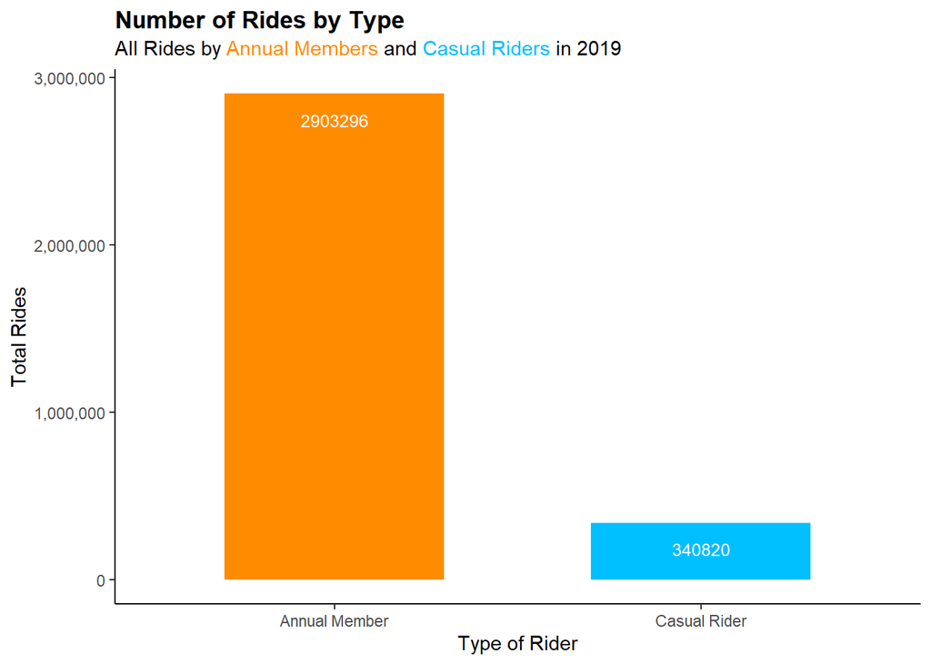

Immediately, a clearer picture emerges of the task ahead. Nearly 90% of Cyclistic customers are *already* members. This leaves just 10% of the customer base that can potentially be converted from casual riders into annual members. These are the riders the Cyclistic marketing team will attempt to reach through this marketing campaign.  
As stated in the Key Analysis Question, the goal is to uncover the differences between casual riders and annual members. In order to do that, it would be helpful to have a better understanding of what the Cyclistic customer base looks like. Grouping all customers by their reported sex instantly reveals that the customer base is heavily skewed toward male riders.

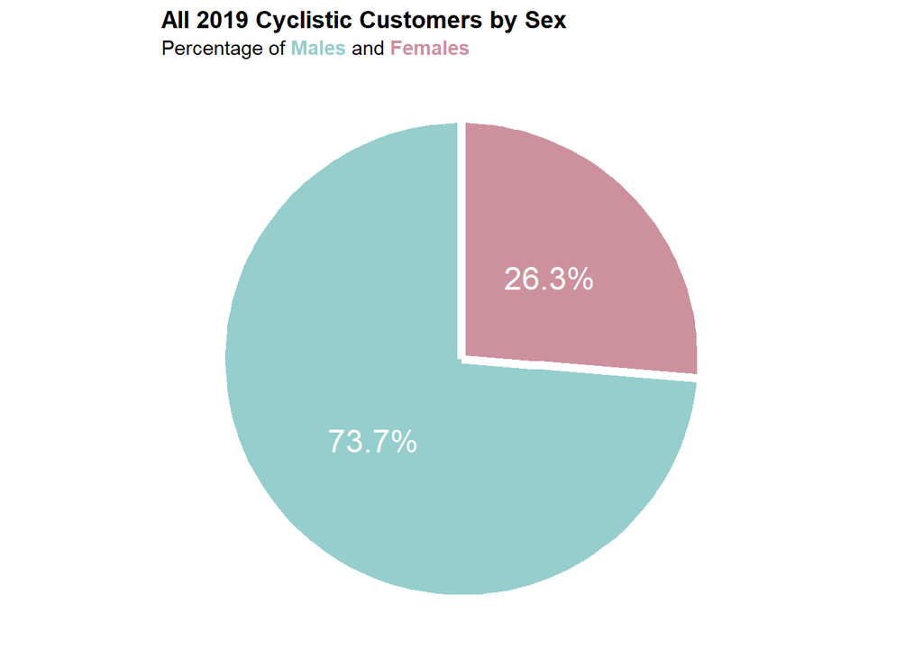

Additionally, grouping the sexes by their membership rates shows that males are more likely to already be annual members.

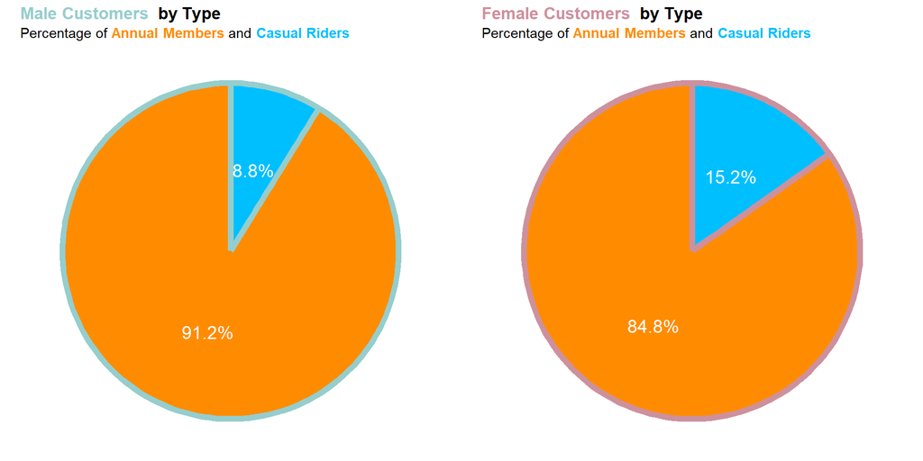

##### Key Insights:

- 90% of customers are annual members
- Males make up nearly three-quarters of Cyclistic’s customer base
- Male customers are annual members at a higher rate (91.2%) than female customers (84.8%)
- While there are more *total* male casual riders, there is a *greater proportion* of casual riders within the female demographic

#### Demographic Breakdown by Age and Sex

Alongside their sex, breaking down customers by their age can be helpful in providing a more detailed picture of the people who make up Cyclistic’s customer base. The following graph shows the membership rates of customers between 18 and 70 years old. Each horizontal bar represents the proportion of male and femlae customers of that age who are annual members. (Customers older than 70 represent just 0.2% of all rides and were excluded from this one graph for sake of clarity). Using the dotted lines as guides, we observe that most customer age groups have a membership rate close to or above 90%. This is especially true for male customers, and for older age groups among both sexes.

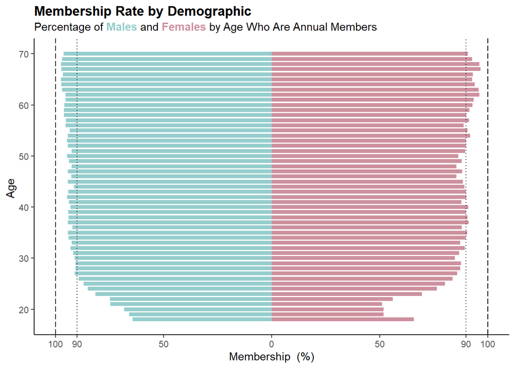

The shorter bars at the bottom of the previous graph stand out. This bottleneck represents a steep decrease in annual membership rates among the youngest age groups. Focusing in on this part of the graph allows for a closer analysis of the demographics with the lowest membership rates.  
Notable observations include: 21-year-old females have the lowest membership rate (51.1%) of any age/sex combination, followed closely by females aged 19 and 20 (both 51.8%). More generally, we observe that the youngest age groups have the lowest membership rates, and that male and female customers aged 18-22 have significantly lower membership rates than their older counterparts.

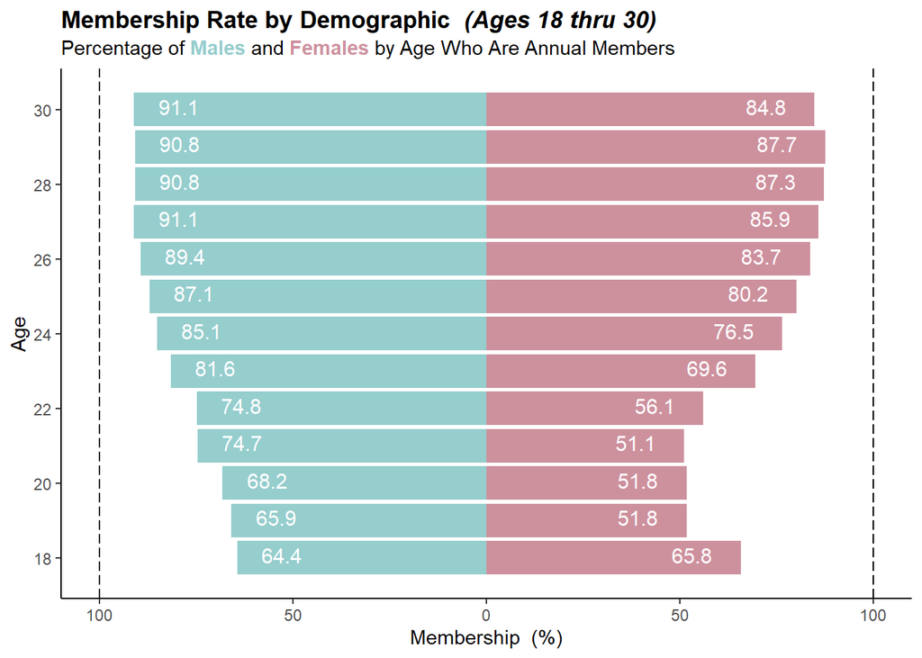

#### When do Rides Occur?

With a better idea of what the customer base looks like, we can now explore how this customer base behaves. Let’s begin by asking *when* customers choose to take rides, and then we will look more closely at the characteristics of the rides themselves.

The following graph shows on which day of the week Cyclistic customers rode their bikes. We observe that more rides were taken during the week as opposed to on weekends. Tuesdays, Wednesdays, and Thursdays saw both the most total rides (approximately 525,000 on each day), as well as the highest proportions of membership (93.2%, 93.1%, and 92.2% respectively). Additionally, we observe that the size of the blue bands atop each bar are relatively equal. This suggests that the raw number of casual riders remained mostly constant for each day of the week, with a bump in casual ridership experienced on the weekends.

```
##        Usertype    Sun    Mon   Tues    Wed   Thur    Fri    Sat
## 1  Casual Rider  62920  40204  35962  36427  40744  46616  77947
## 8 Annual Member 252749 453653 491487 488971 481450 451737 283249
```

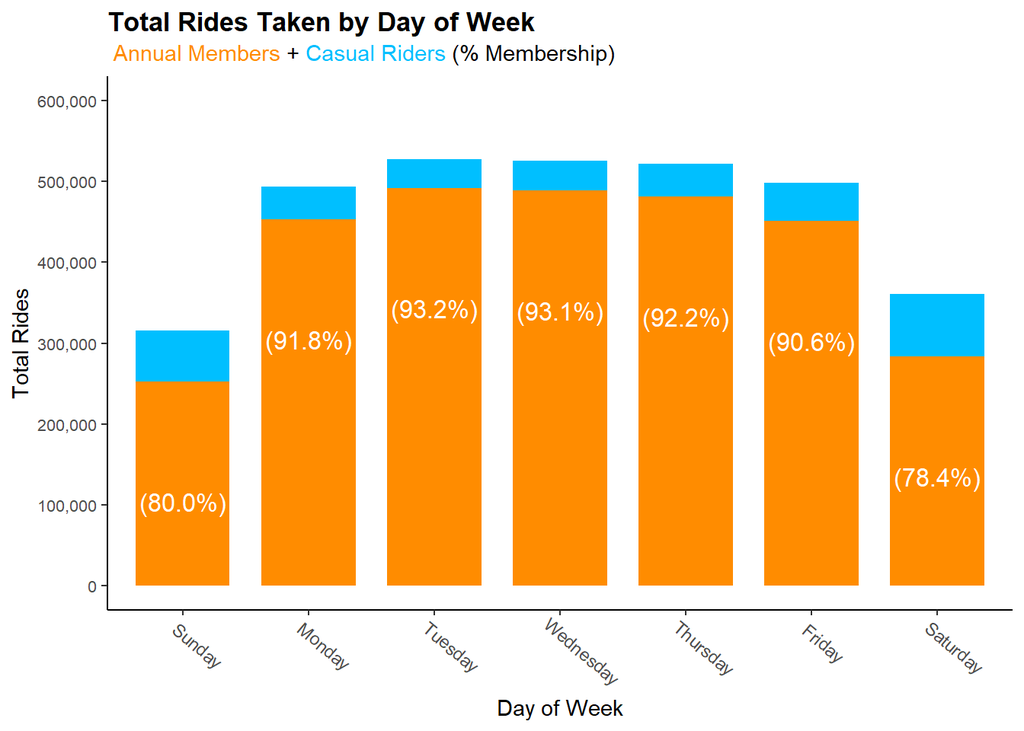

Similarly, we can analyze ridership month-by-month to determine if there are seasonal trends. Unsurprisingly, we find that rider behavior changes drastically depending on what time of year it is. Most rides occur in the summer between June and September. In contrast, we see a sharp drop in ridership between November and February. Moreover, the sizes of the blue bands reveal that casual rides occur almost exclusively in the warmer half of the year (May – October).

```
##         Usertype   Jan   Feb    Mar    Apr    May    Jun    Jul    Aug    Sep
## 1   Casual Rider  1180   728   3971  12984  23522  42143  74593  82449  55113
## 13 Annual Member 97539 92365 148100 215471 282800 341518 376800 398498 359791
##       Oct    Nov    Dec
## 1   30407   7704   6026
## 13 297127 156432 136855
```

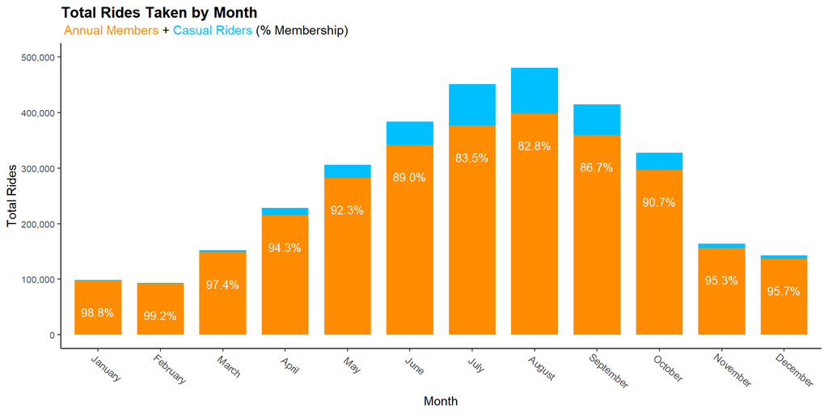

#### Bike Trip Starting Times

We have explored which days of the week and times of year are most popular among the different types of riders. But what does ridership on a typical day look like? The plot below helps answer this question. Each dot represents the percentage of all rides in 2019 that began within that 15-minute time interval (the left-most dots represent rides that began between midnight and 12:15am, the next dots represent rides that began between 12:15 – 12:30am, etc.)

The patterns that emerge are revealing. Annual riders’ trip start-times peak at approximately 8am, and then again at 5pm. This coincides with the start- and end-times of a standard American workday. Additionally, there is a bump between these two peaks that lasts from approximately 12 – 1pm. All of this suggests that a large number of annual members use Cyclistic bikes to commute to and from work, and a smaller, yet still significant, number of members take rides during their midday lunch breaks. This aligns with the earlier observation that annual members take a majority of their rides Monday – Friday.

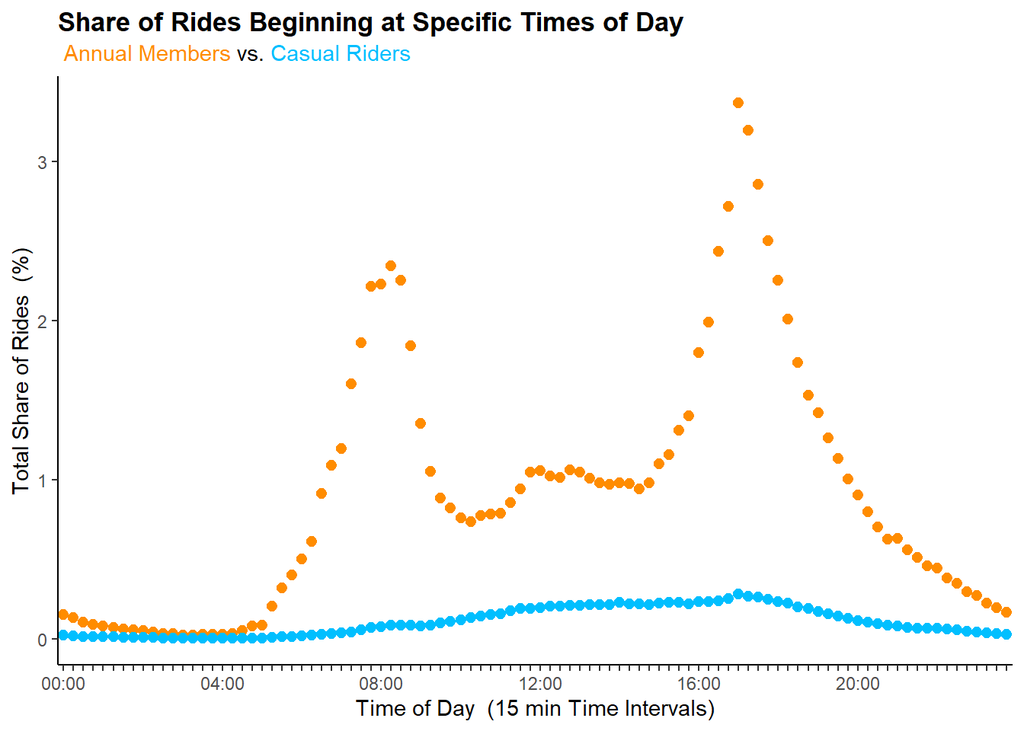

##### Key Insights:

- Start-times for annual members are highly correlated with commute times and lunch breaks
- Casual riders typically do not use Cyclistic bikes to commute to work

#### Ride Duration

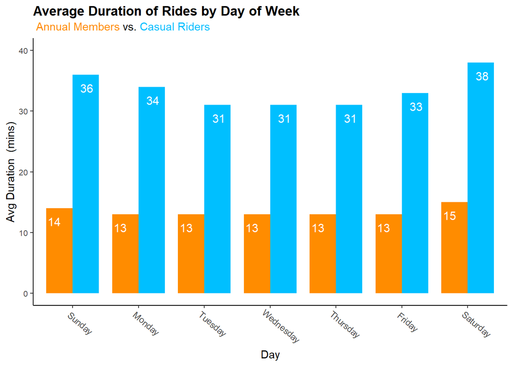

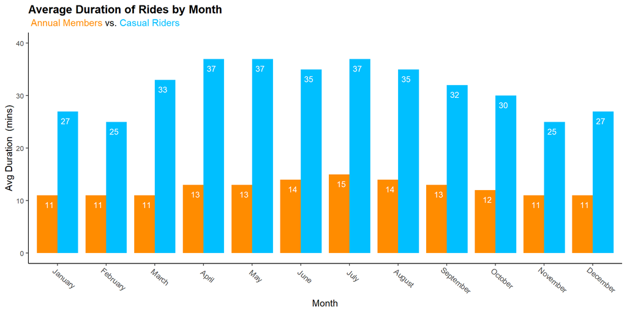

##### Key Insights:

- Casual Customers take longer rides on average than do annual members
- Both types of customers take slightly longer rides on the weekends than during the week
- Both types of customers take longer rides during the warmest months, and shorter bike rides in the coldest months
- On any given day, or within any given month, the average casual bike ride will last approximately 2.5 times longer than the average member’s ride

#### Which Stations do Rides Begin and End at?

Finally, analyzing data about where each trip started and ended can provide valuable information about rider behavior in different parts of the city. In turn, this can help inform the Cyclistic marketing team’s decision about where *exactly* they might want to place advertisements.

The following two graphs show which docking stations annual members are likely to begin and end their trips at. Once again, stations that saw fewer than 300 total trips in 2019 are excluded.

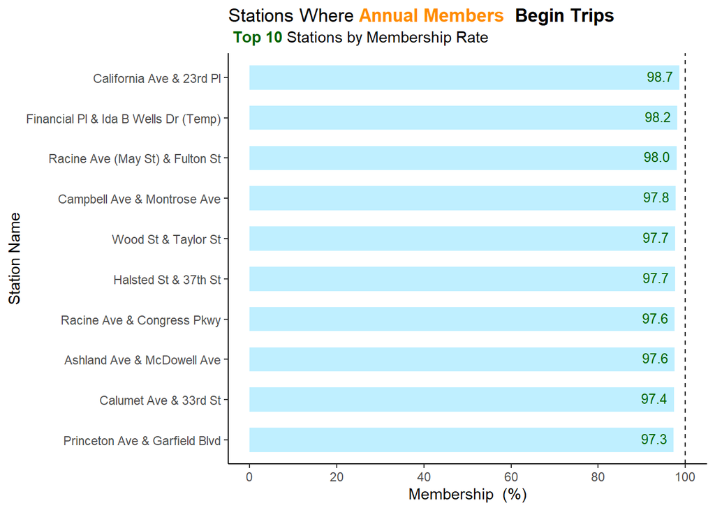

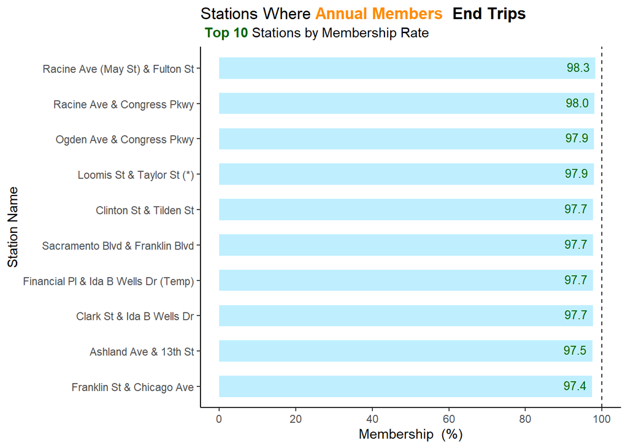

##### Key Insights:

- 3 docking stations show up in the top 10 for both beginning trips and ending trips
- These stations are “Financial Pl & Ida B Wells Dr (Temp)”, “Racine Ave (May St) & Fulton St”, and “Racine Ave & Congress Pkwy”  
  Conversely, we can analyze which stations annual members are *least likely* to start or end at. The following two graphs show the 10 docking stations with the lowest proportion of annual members. Stations that saw fewer than 300 total trips in 2019 are excluded.

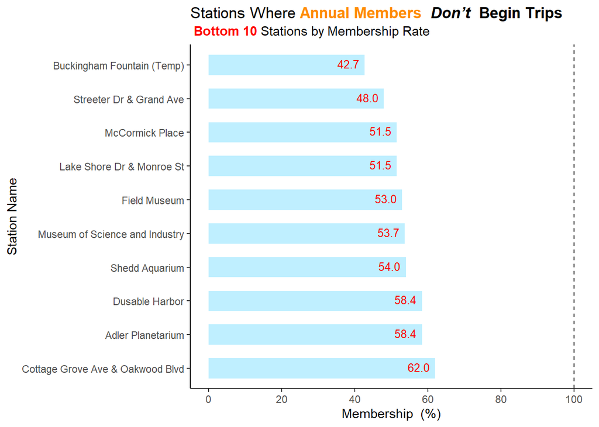

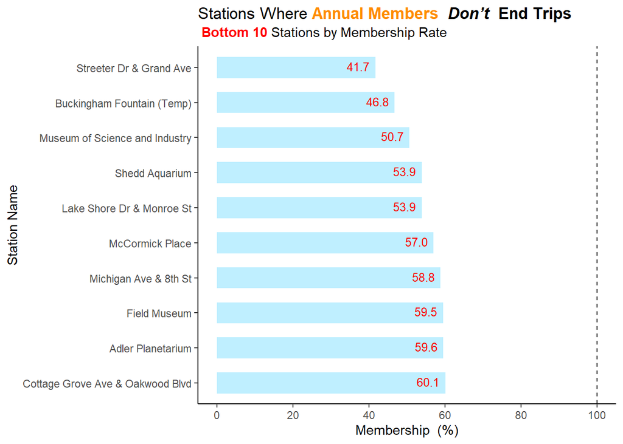

##### Key Insights:

- 9 docking stations show up in the bottom 10 for both beginning trips and ending trips
- These include every station shown in both graphs except for “Dusable Harbor” and “Michigan Ave & 8th St”

## Recommendations

Utilizing the key insights from the analysis above, we can offer the following recommendations to the marketing team to help them achieve the goal of converting casual riders into annual members:

- Aim the marketing campaign at Cyclistic’s youngest customers. Current customers aged 18 – 24 (especially females) are the least likely demographic to already be members.
- Offer deals and/or discounts for customers to become annual members during the summer months. This is when both the largest number and the largest proportion of casual customers go on rides. For an even larger ROI, run advertisements over the summer months *on weekends.*
- Run advertisements in places where commuters will see them (e.g., in subway stations and on buses). This will present them with a fun, healthy, and popular alternative to their normal means of transportation.
- Place advertisements at and around the docking stations that currently boast the lowest membership rates.